In any given experiment there are many variables. There are one or more variables of interest that we would like to understand the consequences of. There are also technical variables that differ between samples because of imperfect instrumentation, experimental practice, etc. Finally, there are biological variables such as genetic, age, and gender differences. Failing to account for these technical and biological sources of variation can lead to faulty conclusions.

In order to reach the correct conclusions, the only option is usually to follow good experimental design. This includes keeping non-desirable variation to a minimum, balancing the remaining sources of variation between experimental groups, and accounting for known sources of variation with statistical models. In general, unknown sources of variation cannot be accounted for. This is not true for microarrays and other high-throughput experiments, where unknown sources of variation can be discovered using the data itself.

This data-driven approach doesn’t necessarily determine the actual unknown variables. Instead, the unknown variables are collectively approximated with a set of surrogate variables. As such, the algorithm is called surrogate variable analysis ([sva](http://journals.plos.org/plosgenetics/article?id=10.1371/journal.pgen.0030161)).

Let’s look at a simulated example of what sva is capable of. For this example, the treatment group has higher expression for 300 genes (figure below - left). There is also unknown genetic variability distributed among both treatment and control groups which reduces the expression of an overlapping set of genes (figure below - middle). Using the expression data, sva discovered one surrogate variable which was regressed out of the expression data (figure below - right). Through sva, we have essentially eliminated the influence of the obscuring genetic variability. Critically, the influence of the treatment under study remains.

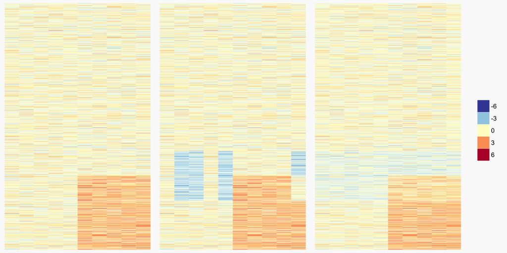

The simplified example above fails to clarify if sva is effective in the messy world of real data. To evaluate sva under more realistic conditions, I used the R package ccmap.

ccmap finds drugs that are predicted to reverse or mimic a query gene expression signature. It does this by ranking 1309 different drugs based on the overlap between their gene expression signatures and a query signature. The drug signatures with the most positive and negative overlap with the query signature are predicted to, respectively, mimic and reverse the query signature.

To evaluate sva using ccmap, I used query signatures from samples that were independently treated with 10 of the 1309 drugs assayed in the ccmap data. These query signatures should have the highest overlap with the ccmap drug signatures for the same drugs. If effective, sva should result in even higher overlap between query and drug signatures for the same drug.

In order to quickly generate a large number of query signatures with and without the use of sva, I used the R package crossmeta. For the 10 evaluation drugs, crossmeta was used to generate differential expression signatures for 259 individual contrasts from 125 studies which were then used to generate a single meta-analysis signature for each drug. As such, the effects of both meta-analysis and surrogate variable analysis were tested.

The results were surprisingly unimpressive for sva. Including sva affected neither the rankings of the queried drugs amongst all other ccmap drugs (figure below - right) nor the overlap between the queried drugs and the same ccmap drugs (figure below - left). In contrast, meta-analysis greatly improved both measures.

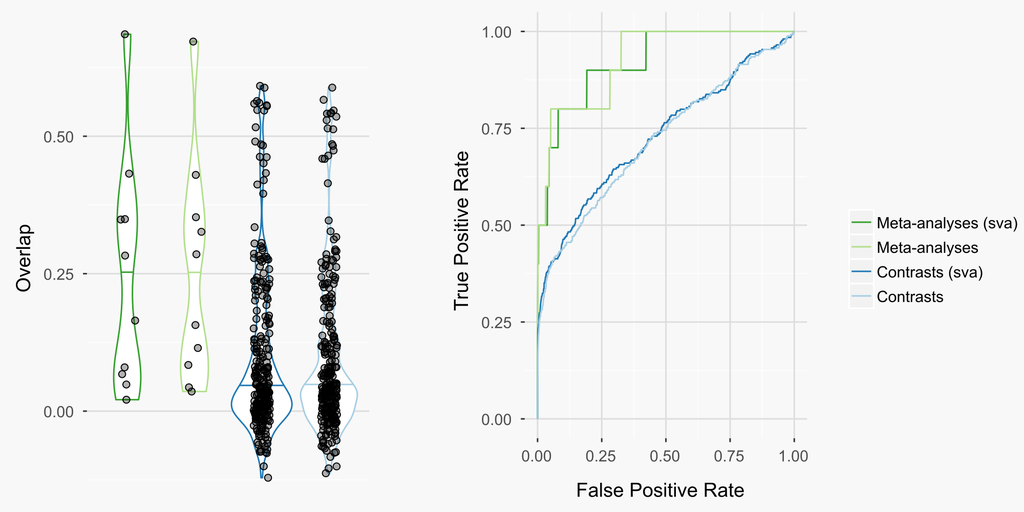

Meta-analysis, but not surrogate variable analysis, increases the overlap (left) and rankings (right) between query and drug expression signatures. On the left each point gives the overlap between a query signature and the ccmap signature for the same drug. Overlaid is a violin plot showing the density and 50th percentile (horizontal line). The ROC curve on the right was generated by calculating the fraction of queried and non-queried drugs that were identified as lower ranks were considered. For each query signature, there was one true positive (the queried drug itself) and 1308 false positives (all other ccmap drugs).

## Summary

Surrogate variable analysis discovers unknown sources of variation in high throughput experiments. Accounting for these sources of variation could potentially prevent faulty conclusions. In this post, I assessed the potential benefits of surrogate variable analysis using a relatively large data set from 125 drug treatment microarray studies. This data set was compared for similarity to a separate reference data set in which the same drugs were assayed. To my surprise, surrogate variable analysis did not appreciably increase the similarity between these comparable data sets. In contrast, the concordance between these two data sets was substantially improved by meta-analysis of studies using the same drugs.